# Analyse Exploratoire des Ventes d'une Chaine de vente d'electroniques

Nous avons dans le dossier datasets/SalesAnalysis des données de ventes d'une entreprise sur l'année 2019. Nous avons un fichier csv par mois.

Chaque fichier contient les colonnes suivantes:

- OrderID: l'identifiant unique de la commande
- Product: La désignation du produit
- Quantity Ordered: la quantité vendue
- Price each: le prix unitaire
- order date: La date d'achat
- Purchase adress: l'adresse de la boutique de vente

Nous allons analyser ces données pour répondre aux questions suivantes:

- Quel est le meilleur mois de vente ? et Quel est le chiffre d'affaires de ce mois ?
- Dans quelle ville a-t-on le plus vendu de produits ?
- A quelle heure devons-nous passer de la publicité pour augmenter nos ventes ?
- Quels sont les produits qui sont souvent achetés ensemble ?
- Quel produit a-t-on le plus vendu et pourquoi ?

Nous allons accompagner nos solutions de visualisations pertinentes afin d'aider le business à améliorer ses chiffres de l'année suivante.

## Importer les données

```python
# importation des bibliotheques
import pandas as pd
import matplotlib.pyplot as plt
import seaborn as sns
import numpy as np

import os
```

```python
data = "datasets/SalesAnalysis/Sales_Data/"
```

```python
os.listdir(data)
```

```
['Sales_April_2019.csv',
 'Sales_August_2019.csv',
 'Sales_December_2019.csv',
 'Sales_February_2019.csv',
 'Sales_January_2019.csv',
 'Sales_July_2019.csv',
 'Sales_June_2019.csv',
 'Sales_March_2019.csv',
 'Sales_May_2019.csv',
 'Sales_November_2019.csv',
 'Sales_October_2019.csv',
 'Sales_September_2019.csv']
```

# Jetons un coup d'oeil à la data d'un mois, celui de Janvier

```python
janvier_sales = pd.read_csv(data + 'Sales_January_2019.csv')
```

```python
janvier_sales.head()
```

|  | Order ID | Product | Quantity Ordered | Price Each | Order Date | Purchase Address |
| --- | --- | --- | --- | --- | --- | --- |
| 0 | 141234 | iPhone | 1 | 700 | 01/22/19 21:25 | 944 Walnut St, Boston, MA 02215 |
| 1 | 141235 | Lightning Charging Cable | 1 | 14.95 | 01/28/19 14:15 | 185 Maple St, Portland, OR 97035 |
| 2 | 141236 | Wired Headphones | 2 | 11.99 | 01/17/19 13:33 | 538 Adams St, San Francisco, CA 94016 |
| 3 | 141237 | 27in FHD Monitor | 1 | 149.99 | 01/05/19 20:33 | 738 10th St, Los Angeles, CA 90001 |
| 4 | 141238 | Wired Headphones | 1 | 11.99 | 01/25/19 11:59 | 387 10th St, Austin, TX 73301 |

```python
janvier_sales.describe()
```

|  | Order ID | Product | Quantity Ordered | Price Each | Order Date | Purchase Address |
| --- | --- | --- | --- | --- | --- | --- |
| count | 9697 | 9697 | 9697 | 9697 | 9697 | 9697 |
| unique | 9269 | 20 | 8 | 19 | 8077 | 9161 |
| top | Order ID | USB-C Charging Cable | 1 | 11.95 | Order Date | Purchase Address |
| freq | 16 | 1171 | 8795 | 1171 | 16 | 16 |

```python
janvier_sales.columns
```

```
Index(['Order ID', 'Product', 'Quantity Ordered', 'Price Each', 'Order Date',
       'Purchase Address'],
      dtype='object')
```

```python
janvier_sales.info()
```

```
<class 'pandas.core.frame.DataFrame'>
RangeIndex: 9723 entries, 0 to 9722
Data columns (total 6 columns):
 #   Column            Non-Null Count  Dtype
---  ------            --------------  -----
 0   Order ID          9697 non-null   object
 1   Product           9697 non-null   object
 2   Quantity Ordered  9697 non-null   object
 3   Price Each        9697 non-null   object
 4   Order Date        9697 non-null   object
 5   Purchase Address  9697 non-null   object
dtypes: object(6)
memory usage: 455.9+ KB
```

# Merger la data

```python
files = [ fichier for fichier in os.listdir(data) if fichier.endswith('.csv')]
files
```

```
['Sales_April_2019.csv',
 'Sales_August_2019.csv',
 'Sales_December_2019.csv',
 'Sales_February_2019.csv',
 'Sales_January_2019.csv',
 'Sales_July_2019.csv',
 'Sales_June_2019.csv',
 'Sales_March_2019.csv',
 'Sales_May_2019.csv',
 'Sales_November_2019.csv',
 'Sales_October_2019.csv',
 'Sales_September_2019.csv']
```

```python
df = pd.DataFrame()
for file in files:
    data_interm = pd.read_csv(data + file)
    df = pd.concat([df, data_interm])
```

```python
df.shape
```

```
(186850, 6)
```

```python
df.describe()
```

|  | Order ID | Product | Quantity Ordered | Price Each | Order Date | Purchase Address |
| --- | --- | --- | --- | --- | --- | --- |
| count | 186305 | 186305 | 186305 | 186305 | 186305 | 186305 |
| unique | 178438 | 20 | 10 | 24 | 142396 | 140788 |
| top | Order ID | USB-C Charging Cable | 1 | 11.95 | Order Date | Purchase Address |
| freq | 355 | 21903 | 168552 | 21903 | 355 | 355 |

```python
df.info()
```

```
<class 'pandas.core.frame.DataFrame'>
Int64Index: 186850 entries, 0 to 11685
Data columns (total 6 columns):
 #   Column            Non-Null Count   Dtype
---  ------            --------------   -----
 0   Order ID          186305 non-null  object
 1   Product           186305 non-null  object
 2   Quantity Ordered  186305 non-null  object
 3   Price Each        186305 non-null  object
 4   Order Date        186305 non-null  object
 5   Purchase Address  186305 non-null  object
dtypes: object(6)
memory usage: 10.0+ MB
```

## Nettoyage de la data

```python
df.isnull().sum(axis=0)
```

```
Order ID            545
Product             545
Quantity Ordered    545
Price Each          545
Order Date          545
Purchase Address    545
dtype: int64
```

**Affichons un df avec toutes les lignes qui ont au moins une valeur manquante**

```python
val_manquantes = df[df.isnull().any(axis=1)]
val_manquantes
```

|  | Order ID | Product | Quantity Ordered | Price Each | Order Date | Purchase Address |
| --- | --- | --- | --- | --- | --- | --- |
| 1 | NaN | NaN | NaN | NaN | NaN | NaN |
| 356 | NaN | NaN | NaN | NaN | NaN | NaN |
| 735 | NaN | NaN | NaN | NaN | NaN | NaN |
| 1433 | NaN | NaN | NaN | NaN | NaN | NaN |
| 1553 | NaN | NaN | NaN | NaN | NaN | NaN |
| ... | ... | ... | ... | ... | ... | ... |
| 10012 | NaN | NaN | NaN | NaN | NaN | NaN |
| 10274 | NaN | NaN | NaN | NaN | NaN | NaN |
| 10878 | NaN | NaN | NaN | NaN | NaN | NaN |
| 11384 | NaN | NaN | NaN | NaN | NaN | NaN |
| 11662 | NaN | NaN | NaN | NaN | NaN | NaN |

545 rows × 6 columns

**Est-ce que toutes les lignes n'ont que des valeurs manquantes**

```python
val_manquantes.isnull().all()
```

```
Order ID            True
Product             True
Quantity Ordered    True
Price Each          True
Order Date          True
Purchase Address    True
dtype: bool
```

```python
df.shape
```

```
(186850, 6)
```

```python
df.dropna(inplace=True)
```

```python
df.shape
```

```
(186305, 6)
```

```python
df.isnull().any()
```

```
Order ID            False
Product             False
Quantity Ordered    False
Price Each          False
Order Date          False
Purchase Address    False
dtype: bool
```

```python
df.describe()
```

|  | Order ID | Product | Quantity Ordered | Price Each | Order Date | Purchase Address |
| --- | --- | --- | --- | --- | --- | --- |
| count | 186305 | 186305 | 186305 | 186305 | 186305 | 186305 |
| unique | 178438 | 20 | 10 | 24 | 142396 | 140788 |
| top | Order ID | USB-C Charging Cable | 1 | 11.95 | Order Date | Purchase Address |
| freq | 355 | 21903 | 168552 | 21903 | 355 | 355 |

**Débarassons-nous des lignes avec des valeurs abérantes**

```python
df[df["Order ID"]=="Order ID"]
```

|  | Order ID | Product | Quantity Ordered | Price Each | Order Date | Purchase Address |
| --- | --- | --- | --- | --- | --- | --- |
| 519 | Order ID | Product | Quantity Ordered | Price Each | Order Date | Purchase Address |
| 1149 | Order ID | Product | Quantity Ordered | Price Each | Order Date | Purchase Address |
| 1155 | Order ID | Product | Quantity Ordered | Price Each | Order Date | Purchase Address |
| 2878 | Order ID | Product | Quantity Ordered | Price Each | Order Date | Purchase Address |
| 2893 | Order ID | Product | Quantity Ordered | Price Each | Order Date | Purchase Address |
| ... | ... | ... | ... | ... | ... | ... |
| 10000 | Order ID | Product | Quantity Ordered | Price Each | Order Date | Purchase Address |
| 10387 | Order ID | Product | Quantity Ordered | Price Each | Order Date | Purchase Address |
| 11399 | Order ID | Product | Quantity Ordered | Price Each | Order Date | Purchase Address |
| 11468 | Order ID | Product | Quantity Ordered | Price Each | Order Date | Purchase Address |
| 11574 | Order ID | Product | Quantity Ordered | Price Each | Order Date | Purchase Address |

355 rows × 6 columns

**La fonction isdigit() return :**

- **True** si tous les caractères de la chaîne sont des chiffres.
- **False** si au moins un caractère n'est pas un chiffre.

```python
print("1548".isdigit())
print("1548K".isdigit())
```

```
True
False
```

```python
df.loc[~df['Order ID'].str.isdigit(), : ]
```

|  | Order ID | Product | Quantity Ordered | Price Each | Order Date | Purchase Address |
| --- | --- | --- | --- | --- | --- | --- |
| 519 | Order ID | Product | Quantity Ordered | Price Each | Order Date | Purchase Address |
| 1149 | Order ID | Product | Quantity Ordered | Price Each | Order Date | Purchase Address |
| 1155 | Order ID | Product | Quantity Ordered | Price Each | Order Date | Purchase Address |
| 2878 | Order ID | Product | Quantity Ordered | Price Each | Order Date | Purchase Address |
| 2893 | Order ID | Product | Quantity Ordered | Price Each | Order Date | Purchase Address |
| ... | ... | ... | ... | ... | ... | ... |
| 10000 | Order ID | Product | Quantity Ordered | Price Each | Order Date | Purchase Address |
| 10387 | Order ID | Product | Quantity Ordered | Price Each | Order Date | Purchase Address |
| 11399 | Order ID | Product | Quantity Ordered | Price Each | Order Date | Purchase Address |
| 11468 | Order ID | Product | Quantity Ordered | Price Each | Order Date | Purchase Address |
| 11574 | Order ID | Product | Quantity Ordered | Price Each | Order Date | Purchase Address |

355 rows × 6 columns

```python
df_clean = df.drop(df.loc[~df['Order ID'].str.isdigit(), : ].index)
```

```python
df_clean.loc[~df_clean['Order ID'].str.isdigit(), : ]
```

|  | Order ID | Product | Quantity Ordered | Price Each | Order Date | Purchase Address |
| --- | --- | --- | --- | --- | --- | --- |

**Changement des Types**

```python
df_clean.head()
```

|  | Order ID | Product | Quantity Ordered | Price Each | Order Date | Purchase Address |
| --- | --- | --- | --- | --- | --- | --- |
| 0 | 176558 | USB-C Charging Cable | 2 | 11.95 | 04/19/19 08:46 | 917 1st St, Dallas, TX 75001 |
| 2 | 176559 | Bose SoundSport Headphones | 1 | 99.99 | 04/07/19 22:30 | 682 Chestnut St, Boston, MA 02215 |
| 3 | 176560 | Google Phone | 1 | 600 | 04/12/19 14:38 | 669 Spruce St, Los Angeles, CA 90001 |
| 4 | 176560 | Wired Headphones | 1 | 11.99 | 04/12/19 14:38 | 669 Spruce St, Los Angeles, CA 90001 |
| 5 | 176561 | Wired Headphones | 1 | 11.99 | 04/30/19 09:27 | 333 8th St, Los Angeles, CA 90001 |

```python
df_clean['Quantity Ordered'] = df_clean['Quantity Ordered'].astype('int')
```

```python
df_clean['Price Each'] = pd.to_numeric(df_clean['Price Each'])
```

```python
df_clean['Order Date'] = pd.to_datetime(df_clean['Order Date'])
```

```python
df_clean.info()
```

```
<class 'pandas.core.frame.DataFrame'>
Int64Index: 182735 entries, 0 to 11685
Data columns (total 6 columns):
 #   Column            Non-Null Count   Dtype
---  ------            --------------   -----
 0   Order ID          182735 non-null  object
 1   Product           182735 non-null  object
 2   Quantity Ordered  182735 non-null  int32
 3   Price Each        182735 non-null  float64
 4   Order Date        182735 non-null  datetime64[ns]
 5   Purchase Address  182735 non-null  object
dtypes: datetime64[ns](1), float64(1), int32(1), object(3)
memory usage: 9.1+ MB
```

```python
df['Order Date']
```

```
0        04/19/19 08:46
2        04/07/19 22:30
3        04/12/19 14:38
4        04/12/19 14:38
5        04/30/19 09:27
              ...
11681    09/17/19 20:56
11682    09/01/19 16:00
11683    09/23/19 07:39
11684    09/19/19 17:30
11685    09/30/19 00:18
Name: Order Date, Length: 186305, dtype: object
```

```python
df_clean['Order Date']
```

```
0       2019-04-19 08:46:00
2       2019-04-07 22:30:00
3       2019-04-12 14:38:00
4       2019-04-12 14:38:00
5       2019-04-30 09:27:00
                ...
11681   2019-09-17 20:56:00
11682   2019-09-01 16:00:00
11683   2019-09-23 07:39:00
11684   2019-09-19 17:30:00
11685   2019-09-30 00:18:00
Name: Order Date, Length: 182735, dtype: datetime64[ns]
```

## Analyse Exploratoire proprement dite

## Quel est le meilleur mois de vente ? et Quel est le chiffre d'affaires de ce mois ?

```python
df_clean.head()
```

|  | Order ID | Product | Quantity Ordered | Price Each | Order Date | Purchase Address |
| --- | --- | --- | --- | --- | --- | --- |
| 0 | 176558 | USB-C Charging Cable | 2 | 11.95 | 2019-04-19 08:46:00 | 917 1st St, Dallas, TX 75001 |
| 2 | 176559 | Bose SoundSport Headphones | 1 | 99.99 | 2019-04-07 22:30:00 | 682 Chestnut St, Boston, MA 02215 |
| 3 | 176560 | Google Phone | 1 | 600.00 | 2019-04-12 14:38:00 | 669 Spruce St, Los Angeles, CA 90001 |
| 4 | 176560 | Wired Headphones | 1 | 11.99 | 2019-04-12 14:38:00 | 669 Spruce St, Los Angeles, CA 90001 |
| 5 | 176561 | Wired Headphones | 1 | 11.99 | 2019-04-30 09:27:00 | 333 8th St, Los Angeles, CA 90001 |

```python
df_clean.index
```

```
Int64Index([    0,     2,     3,     4,     5,     6,     7,     8,     9,
               10,
            ...
            11676, 11677, 11678, 11679, 11680, 11681, 11682, 11683, 11684,
            11685],
           dtype='int64', length=182735)
```

```python
df_clean  = df_clean.set_index('Order Date')
```

```python
df_clean.head()
```

| Order Date | Order ID | Product | Quantity Ordered | Price Each | Purchase Address |
| --- | --- | --- | --- | --- | --- |
| 2019-04-19 08:46:00 | 176558 | USB-C Charging Cable | 2 | 11.95 | 917 1st St, Dallas, TX 75001 |
| 2019-04-07 22:30:00 | 176559 | Bose SoundSport Headphones | 1 | 99.99 | 682 Chestnut St, Boston, MA 02215 |
| 2019-04-12 14:38:00 | 176560 | Google Phone | 1 | 600.00 | 669 Spruce St, Los Angeles, CA 90001 |
| 2019-04-12 14:38:00 | 176560 | Wired Headphones | 1 | 11.99 | 669 Spruce St, Los Angeles, CA 90001 |
| 2019-04-30 09:27:00 | 176561 | Wired Headphones | 1 | 11.99 | 333 8th St, Los Angeles, CA 90001 |

```python
df_clean.sort_index(inplace=True)
```

```python
df_clean.head()
```

| Order Date | Order ID | Product | Quantity Ordered | Price Each | Purchase Address |
| --- | --- | --- | --- | --- | --- |
| 2019-01-01 03:07:00 | 147268 | Wired Headphones | 1 | 11.99 | 9 Lake St, New York City, NY 10001 |
| 2019-01-01 03:40:00 | 148041 | USB-C Charging Cable | 1 | 11.95 | 760 Church St, San Francisco, CA 94016 |
| 2019-01-01 04:56:00 | 149343 | Apple Airpods Headphones | 1 | 150.00 | 735 5th St, New York City, NY 10001 |
| 2019-01-01 05:53:00 | 149964 | AAA Batteries (4-pack) | 1 | 2.99 | 75 Jackson St, Dallas, TX 75001 |
| 2019-01-01 06:03:00 | 149350 | USB-C Charging Cable | 2 | 11.95 | 943 2nd St, Atlanta, GA 30301 |

```python
df_clean['Month'] = df_clean.index.month_name()
```

```python
df_clean.head()
```

| Order Date | Order ID | Product | Quantity Ordered | Price Each | Purchase Address | Month |
| --- | --- | --- | --- | --- | --- | --- |
| 2019-01-01 03:07:00 | 147268 | Wired Headphones | 1 | 11.99 | 9 Lake St, New York City, NY 10001 | January |
| 2019-01-01 03:40:00 | 148041 | USB-C Charging Cable | 1 | 11.95 | 760 Church St, San Francisco, CA 94016 | January |
| 2019-01-01 04:56:00 | 149343 | Apple Airpods Headphones | 1 | 150.00 | 735 5th St, New York City, NY 10001 | January |
| 2019-01-01 05:53:00 | 149964 | AAA Batteries (4-pack) | 1 | 2.99 | 75 Jackson St, Dallas, TX 75001 | January |
| 2019-01-01 06:03:00 | 149350 | USB-C Charging Cable | 2 | 11.95 | 943 2nd St, Atlanta, GA 30301 | January |

```python
df_clean['chiffre_daffaire'] = df_clean['Quantity Ordered'] * df_clean['Price Each']
```

```python
df_clean.sample(5)
```

| Order Date | Order ID | Product | Quantity Ordered | Price Each | Purchase Address | Month | chiffre_daffaire |
| --- | --- | --- | --- | --- | --- | --- | --- |
| 2019-11-12 01:43:00 | 290200 | Apple Airpods Headphones | 1 | 150.00 | 873 Walnut St, Los Angeles, CA 90001 | November | 150.00 |
| 2019-06-06 12:00:00 | 213529 | 27in FHD Monitor | 1 | 149.99 | 521 Wilson St, Los Angeles, CA 90001 | June | 149.99 |
| 2019-05-17 13:09:00 | 201190 | Macbook Pro Laptop | 1 | 1700.00 | 588 Wilson St, Portland, OR 97035 | May | 1700.00 |
| 2019-11-08 18:52:00 | 285974 | USB-C Charging Cable | 1 | 11.95 | 667 13th St, Seattle, WA 98101 | November | 11.95 |
| 2019-09-08 07:55:00 | 259105 | Wired Headphones | 1 | 11.99 | 772 Hickory St, San Francisco, CA 94016 | September | 11.99 |

```python
df_clean.groupby('Month')["chiffre_daffaire"].sum().sort_values(ascending=False)
```

```
Month
December     4557905.42
October      3679254.16
April        3336376.42
November     3149785.09
May          3101881.04
March        2755969.40
July         2587444.91
June         2524464.99
August       2191698.31
February     2158127.48
September    2050361.26
January      1786511.29
Name: chiffre_daffaire, dtype: float64
```

```python
order = ["January", "February", "March", "April", "May", "June", "July", "August",
                  "September", "October", "November", "December"]
```

```python
df_clean.groupby('Month')["chiffre_daffaire"].sum().loc[order]
```

```
Month
January      1786511.29
February     2158127.48
March        2755969.40
April        3336376.42
May          3101881.04
June         2524464.99
July         2587444.91
August       2191698.31
September    2050361.26
October      3679254.16
November     3149785.09
December     4557905.42
Name: chiffre_daffaire, dtype: float64
```

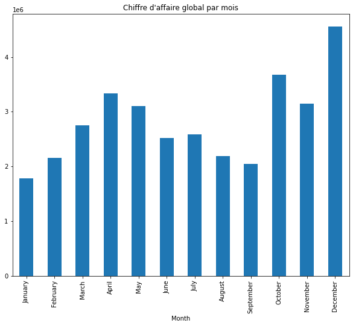

```python
df_clean.groupby('Month')["chiffre_daffaire"].sum().loc[order].plot.bar(figsize=(10, 8))
plt.title("Chiffre d'affaire global par mois")
```

```python
df_clean.groupby('Month').sum()["chiffre_daffaire"].sort_values(ascending=False).December
```

```
4557905.42
```

**Décembre est le mois avec le plus de ventes et le CA est de 4557905.420001525**

## Dans quelle ville a-t-on le plus vendu de produits ?

```python
df_clean.head()
```

| Order Date | Order ID | Product | Quantity Ordered | Price Each | Purchase Address | Month | chiffre_daffaire |
| --- | --- | --- | --- | --- | --- | --- | --- |
| 2019-01-01 03:07:00 | 147268 | Wired Headphones | 1 | 11.99 | 9 Lake St, New York City, NY 10001 | January | 11.99 |
| 2019-01-01 03:40:00 | 148041 | USB-C Charging Cable | 1 | 11.95 | 760 Church St, San Francisco, CA 94016 | January | 11.95 |
| 2019-01-01 04:56:00 | 149343 | Apple Airpods Headphones | 1 | 150.00 | 735 5th St, New York City, NY 10001 | January | 150.00 |
| 2019-01-01 05:53:00 | 149964 | AAA Batteries (4-pack) | 1 | 2.99 | 75 Jackson St, Dallas, TX 75001 | January | 2.99 |
| 2019-01-01 06:03:00 | 149350 | USB-C Charging Cable | 2 | 11.95 | 943 2nd St, Atlanta, GA 30301 | January | 23.90 |

```python
df_clean['Purchase Address'].unique()
```

```
array(['9 Lake St, New York City, NY 10001',
       '760 Church St, San Francisco, CA 94016',
       '735 5th St, New York City, NY 10001', ...,
       '731 7th St, New York City, NY 10001',
       '754 Hickory St, New York City, NY 10001',
       '657 Spruce St, New York City, NY 10001'], dtype=object)
```

```python
def get_ville(addresse):
  return addresse.split(',')[1].strip()
```

```python
"        Kototo        ".strip()
```

```
'Kototo'
```

```python
get_ville("760 Church St, San Francisco, CA 94016")
```

```
'San Francisco'
```

```python
df_clean['Ville'] = df_clean['Purchase Address'].apply(get_ville)
```

```python
df_clean.sample(5)
```

| Order Date | Order ID | Product | Quantity Ordered | Price Each | Purchase Address | Month | chiffre_daffaire | Ville |
| --- | --- | --- | --- | --- | --- | --- | --- | --- |
| 2019-10-18 20:56:00 | 277142 | Lightning Charging Cable | 1 | 14.95 | 658 Willow St, Austin, TX 73301 | October | 14.95 | Austin |
| 2019-07-09 19:06:00 | 224253 | Lightning Charging Cable | 1 | 14.95 | 739 Main St, Los Angeles, CA 90001 | July | 14.95 | Los Angeles |
| 2019-03-20 15:26:00 | 172144 | USB-C Charging Cable | 1 | 11.95 | 86 Jackson St, Portland, ME 04101 | March | 11.95 | Portland |
| 2019-07-22 18:37:00 | 226261 | AAA Batteries (4-pack) | 2 | 2.99 | 740 Forest St, Austin, TX 73301 | July | 5.98 | Austin |
| 2019-02-02 09:30:00 | 154201 | AA Batteries (4-pack) | 2 | 3.84 | 826 Willow St, San Francisco, CA 94016 | February | 7.68 | San Francisco |

```python
df_clean['Ville'].unique()
```

```
array(['New York City', 'San Francisco', 'Dallas', 'Atlanta', 'Boston',
       'Seattle', 'Los Angeles', 'Portland', 'Austin'], dtype=object)
```

```python
df_clean.groupby('Ville')['chiffre_daffaire'].sum().sort_values(ascending=False)
```

```
Ville
San Francisco    8124120.94
Los Angeles      5354039.93
New York City    4581658.91
Boston           3604080.86
Atlanta          2741642.05
Dallas           2717793.72
Seattle          2693048.60
Portland         2276649.24
Austin           1786745.52
Name: chiffre_daffaire, dtype: float64
```

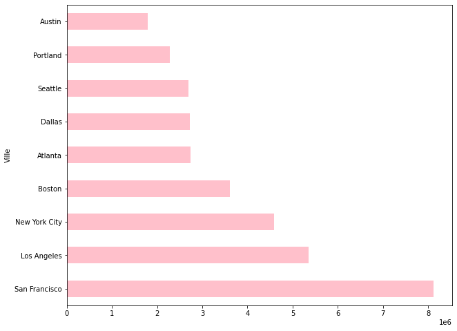

```python
df_clean.groupby('Ville')["chiffre_daffaire"].sum().sort_values(ascending=False).plot.barh(color="pink",figsize=(10, 8))
```

**On a fait un meilleur chiffre d'affaire à San Francisco**

```python
ca_by_ville = df_clean.groupby('Ville').sum()["chiffre_daffaire"].sort_values(ascending=False)
```

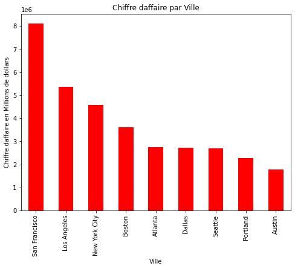

```python
ca_by_ville.plot(kind='bar',color="red", figsize=(8, 6))
plt.ylabel('Chiffre daffaire en Millions de dollars')
plt.title('Chiffre daffaire par Ville')
plt.show()
```

## A quelle heure devons-nous passer de la publicité pour augmenter nos ventes ?

```python
df_clean.head()
```

| Order Date | Order ID | Product | Quantity Ordered | Price Each | Purchase Address | Month | chiffre_daffaire | Ville |
| --- | --- | --- | --- | --- | --- | --- | --- | --- |
| 2019-01-01 03:07:00 | 147268 | Wired Headphones | 1 | 11.99 | 9 Lake St, New York City, NY 10001 | January | 11.99 | New York City |
| 2019-01-01 03:40:00 | 148041 | USB-C Charging Cable | 1 | 11.95 | 760 Church St, San Francisco, CA 94016 | January | 11.95 | San Francisco |
| 2019-01-01 04:56:00 | 149343 | Apple Airpods Headphones | 1 | 150.00 | 735 5th St, New York City, NY 10001 | January | 150.00 | New York City |
| 2019-01-01 05:53:00 | 149964 | AAA Batteries (4-pack) | 1 | 2.99 | 75 Jackson St, Dallas, TX 75001 | January | 2.99 | Dallas |
| 2019-01-01 06:03:00 | 149350 | USB-C Charging Cable | 2 | 11.95 | 943 2nd St, Atlanta, GA 30301 | January | 23.90 | Atlanta |

**A quelle heure on vend le plus ?**

```python
df_clean['heure'] = df_clean.index.hour
df_clean['time'] = df_clean.index.time
```

```python
df_clean.head()
```

| Order Date | Order ID | Product | Quantity Ordered | Price Each | Purchase Address | Month | chiffre_daffaire | Ville | heure | time |
| --- | --- | --- | --- | --- | --- | --- | --- | --- | --- | --- |
| 2019-01-01 03:07:00 | 147268 | Wired Headphones | 1 | 11.99 | 9 Lake St, New York City, NY 10001 | January | 11.99 | New York City | 3 | 03:07:00 |
| 2019-01-01 03:40:00 | 148041 | USB-C Charging Cable | 1 | 11.95 | 760 Church St, San Francisco, CA 94016 | January | 11.95 | San Francisco | 3 | 03:40:00 |
| 2019-01-01 04:56:00 | 149343 | Apple Airpods Headphones | 1 | 150.00 | 735 5th St, New York City, NY 10001 | January | 150.00 | New York City | 4 | 04:56:00 |
| 2019-01-01 05:53:00 | 149964 | AAA Batteries (4-pack) | 1 | 2.99 | 75 Jackson St, Dallas, TX 75001 | January | 2.99 | Dallas | 5 | 05:53:00 |
| 2019-01-01 06:03:00 | 149350 | USB-C Charging Cable | 2 | 11.95 | 943 2nd St, Atlanta, GA 30301 | January | 23.90 | Atlanta | 6 | 06:03:00 |

```python
df_clean.groupby('heure')['chiffre_daffaire'].sum().sort_values(ascending=False)
```

```
heure
19    2370005.59
12    2269676.91
11    2267169.73
20    2242856.37
18    2176209.65
13    2118394.83
17    2086082.23
14    2045085.42
21    2013288.02
10    1907179.29
15    1900151.56
16    1864530.92
9     1612498.90
22    1578173.21
8     1181363.76
23    1161803.96
7      734595.75
0      698694.76
1      447663.86
6      441523.14
2      234191.08
5      224313.72
4      161350.57
3      142976.54
Name: chiffre_daffaire, dtype: float64
```

```python
ca_par_heure = pd.DataFrame(df_clean.groupby('heure')['chiffre_daffaire'].sum())
```

```python
ca_par_heure
```

| heure | chiffre_daffaire |
| --- | --- |
| 0 | 698694.76 |
| 1 | 447663.86 |
| 2 | 234191.08 |
| 3 | 142976.54 |
| 4 | 161350.57 |
| 5 | 224313.72 |
| 6 | 441523.14 |
| 7 | 734595.75 |
| 8 | 1181363.76 |
| 9 | 1612498.90 |
| 10 | 1907179.29 |
| 11 | 2267169.73 |
| 12 | 2269676.91 |
| 13 | 2118394.83 |
| 14 | 2045085.42 |
| 15 | 1900151.56 |
| 16 | 1864530.92 |
| 17 | 2086082.23 |
| 18 | 2176209.65 |
| 19 | 2370005.59 |
| 20 | 2242856.37 |
| 21 | 2013288.02 |
| 22 | 1578173.21 |
| 23 | 1161803.96 |

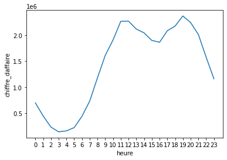

```python
sns.lineplot(data=ca_par_heure['chiffre_daffaire'])
plt.xticks(ticks=range(0, 24))
plt.show()
```

**On devrait afficher la publicité entre 10 et 11 et entre 18 et 19.**

## Quels sont les produits qui sont souvent achetés ensemble ?

**Les produits vendus ensemble ont le même Order ID.**

```python
df_clean.head()
```

| Order Date | Order ID | Product | Quantity Ordered | Price Each | Purchase Address | Month | chiffre_daffaire | Ville | heure | time |
| --- | --- | --- | --- | --- | --- | --- | --- | --- | --- | --- |
| 2019-01-01 03:07:00 | 147268 | Wired Headphones | 1 | 11.99 | 9 Lake St, New York City, NY 10001 | January | 11.99 | New York City | 3 | 03:07:00 |
| 2019-01-01 03:40:00 | 148041 | USB-C Charging Cable | 1 | 11.95 | 760 Church St, San Francisco, CA 94016 | January | 11.95 | San Francisco | 3 | 03:40:00 |
| 2019-01-01 04:56:00 | 149343 | Apple Airpods Headphones | 1 | 150.00 | 735 5th St, New York City, NY 10001 | January | 150.00 | New York City | 4 | 04:56:00 |
| 2019-01-01 05:53:00 | 149964 | AAA Batteries (4-pack) | 1 | 2.99 | 75 Jackson St, Dallas, TX 75001 | January | 2.99 | Dallas | 5 | 05:53:00 |
| 2019-01-01 06:03:00 | 149350 | USB-C Charging Cable | 2 | 11.95 | 943 2nd St, Atlanta, GA 30301 | January | 23.90 | Atlanta | 6 | 06:03:00 |

**Les ventes avec plus d'un produit :**

```python
df_m = df_clean[df_clean['Order ID'].duplicated(keep=False)].copy()
df_m
```

| Order Date | Order ID | Product | Quantity Ordered | Price Each | Purchase Address | Month | chiffre_daffaire | Ville | heure | time |
| --- | --- | --- | --- | --- | --- | --- | --- | --- | --- | --- |
| 2019-01-01 07:29:00 | 144804 | Wired Headphones | 1 | 11.99 | 628 Lake St, New York City, NY 10001 | January | 11.99 | New York City | 7 | 07:29:00 |
| 2019-01-01 07:29:00 | 144804 | iPhone | 1 | 700.00 | 628 Lake St, New York City, NY 10001 | January | 700.00 | New York City | 7 | 07:29:00 |
| 2019-01-01 11:25:00 | 148074 | USB-C Charging Cable | 1 | 11.95 | 6 Johnson St, Atlanta, GA 30301 | January | 11.95 | Atlanta | 11 | 11:25:00 |
| 2019-01-01 11:25:00 | 148074 | Google Phone | 1 | 600.00 | 6 Johnson St, Atlanta, GA 30301 | January | 600.00 | Atlanta | 11 | 11:25:00 |
| 2019-01-01 12:02:00 | 148450 | iPhone | 1 | 700.00 | 761 Lakeview St, Dallas, TX 75001 | January | 700.00 | Dallas | 12 | 12:02:00 |
| ... | ... | ... | ... | ... | ... | ... | ... | ... | ... | ... |
| 2020-01-01 00:10:00 | 311386 | Apple Airpods Headphones | 1 | 150.00 | 730 Pine St, San Francisco, CA 94016 | January | 150.00 | San Francisco | 0 | 00:10:00 |
| 2020-01-01 00:22:00 | 297817 | Lightning Charging Cable | 2 | 14.95 | 519 13th St, New York City, NY 10001 | January | 29.90 | New York City | 0 | 00:22:00 |
| 2020-01-01 00:22:00 | 297817 | iPhone | 1 | 700.00 | 519 13th St, New York City, NY 10001 | January | 700.00 | New York City | 0 | 00:22:00 |
| 2020-01-01 05:13:00 | 300519 | Bose SoundSport Headphones | 1 | 99.99 | 657 Spruce St, New York City, NY 10001 | January | 99.99 | New York City | 5 | 05:13:00 |
| 2020-01-01 05:13:00 | 300519 | Lightning Charging Cable | 1 | 14.95 | 657 Spruce St, New York City, NY 10001 | January | 14.95 | New York City | 5 | 05:13:00 |

14214 rows × 10 columns

```python
df_m = df_clean[df_clean.duplicated(keep=False)].copy()
df_m
#df_m.columns.to_list()
#dups_nimi = df_m.pivot_table(columns=df_m.columns.to_list(),aggfunc="size")
#dups_nimi.to_frame()
```

| Order Date | Order ID | Product | Quantity Ordered | Price Each | Purchase Address | Month | chiffre_daffaire | Ville | heure | time |
| --- | --- | --- | --- | --- | --- | --- | --- | --- | --- | --- |
| 2019-01-02 23:07:00 | 149308 | Apple Airpods Headphones | 1 | 150.00 | 351 Madison St, New York City, NY 10001 | January | 150.00 | New York City | 23 | 23:07:00 |
| 2019-01-02 23:07:00 | 149308 | Apple Airpods Headphones | 1 | 150.00 | 351 Madison St, New York City, NY 10001 | January | 150.00 | New York City | 23 | 23:07:00 |
| 2019-01-04 16:50:00 | 147707 | Wired Headphones | 1 | 11.99 | 883 4th St, Dallas, TX 75001 | January | 11.99 | Dallas | 16 | 16:50:00 |
| 2019-01-04 16:50:00 | 147707 | Wired Headphones | 1 | 11.99 | 883 4th St, Dallas, TX 75001 | January | 11.99 | Dallas | 16 | 16:50:00 |
| 2019-01-06 03:01:00 | 145143 | Lightning Charging Cable | 1 | 14.95 | 182 Jefferson St, San Francisco, CA 94016 | January | 14.95 | San Francisco | 3 | 03:01:00 |
| ... | ... | ... | ... | ... | ... | ... | ... | ... | ... | ... |
| 2019-12-30 16:52:00 | 296081 | Flatscreen TV | 1 | 300.00 | 970 Sunset St, Austin, TX 73301 | December | 300.00 | Austin | 16 | 16:52:00 |
| 2019-12-31 10:18:00 | 308362 | AAA Batteries (4-pack) | 1 | 2.99 | 914 Pine St, San Francisco, CA 94016 | December | 2.99 | San Francisco | 10 | 10:18:00 |
| 2019-12-31 10:18:00 | 308362 | AAA Batteries (4-pack) | 1 | 2.99 | 914 Pine St, San Francisco, CA 94016 | December | 2.99 | San Francisco | 10 | 10:18:00 |
| 2019-12-31 10:58:00 | 305423 | Wired Headphones | 1 | 11.99 | 702 Chestnut St, San Francisco, CA 94016 | December | 11.99 | San Francisco | 10 | 10:58:00 |
| 2019-12-31 10:58:00 | 305423 | Wired Headphones | 1 | 11.99 | 702 Chestnut St, San Francisco, CA 94016 | December | 11.99 | San Francisco | 10 | 10:58:00 |

518 rows × 10 columns

```python
def concat_produit_par_order_id(p: list):
  return ";".join(p)
```

```python
df_m.groupby('Order ID')['Product'].apply(concat_produit_par_order_id)
```

```
Order ID
142071          AA Batteries (4-pack);AA Batteries (4-pack)
145143    Lightning Charging Cable;Lightning Charging Cable
146765                            Google Phone;Google Phone
147707                    Wired Headphones;Wired Headphones
148984            USB-C Charging Cable;USB-C Charging Cable
                                ...
314675          AA Batteries (4-pack);AA Batteries (4-pack)
315204                    Wired Headphones;Wired Headphones
315955                      ThinkPad Laptop;ThinkPad Laptop
316173        AAA Batteries (4-pack);AAA Batteries (4-pack)
317971          AA Batteries (4-pack);AA Batteries (4-pack)
Name: Product, Length: 259, dtype: object
```

```python
ensemble = df_m.groupby('Order ID')['Product'].apply(concat_produit_par_order_id)
```

```python
from itertools import combinations
from collections import Counter

count = Counter()
```

```python
Counter(combinations(['a', 'c', 'b'], 2))
```

```
Counter({('a', 'c'): 1, ('a', 'b'): 1, ('c', 'b'): 1})
```

```python
for i, j in combinations(['a', 'c', 'b'], 2):
    print(i, j)
```

```
a c
a b
c b
```

```python
ensemble.to_list()
```

```
['AA Batteries (4-pack);AA Batteries (4-pack)',
 'Lightning Charging Cable;Lightning Charging Cable',
 'Google Phone;Google Phone',
 'Wired Headphones;Wired Headphones',
 'USB-C Charging Cable;USB-C Charging Cable',
 'Lightning Charging Cable;Lightning Charging Cable',
 'Apple Airpods Headphones;Apple Airpods Headphones',
 'USB-C Charging Cable;USB-C Charging Cable',
 'USB-C Charging Cable;USB-C Charging Cable',
 'Wired Headphones;Wired Headphones',
 'Lightning Charging Cable;Lightning Charging Cable',
 'iPhone;iPhone',
 'USB-C Charging Cable;USB-C Charging Cable',
 'Wired Headphones;Wired Headphones',
 'USB-C Charging Cable;USB-C Charging Cable',
 'Wired Headphones;Wired Headphones',
 'USB-C Charging Cable;USB-C Charging Cable',
 'Bose SoundSport Headphones;Bose SoundSport Headphones',
 'Wired Headphones;Wired Headphones',
 'Wired Headphones;Wired Headphones',
 'Lightning Charging Cable;Lightning Charging Cable',
 '27in 4K Gaming Monitor;27in 4K Gaming Monitor',
 'AA Batteries (4-pack);AA Batteries (4-pack)',
 'Bose SoundSport Headphones;Bose SoundSport Headphones',
 'AAA Batteries (4-pack);AAA Batteries (4-pack)',
 'AA Batteries (4-pack);AA Batteries (4-pack)',
 '34in Ultrawide Monitor;34in Ultrawide Monitor',
 'Flatscreen TV;Flatscreen TV',
 'AAA Batteries (4-pack);AAA Batteries (4-pack)',
 'Bose SoundSport Headphones;Bose SoundSport Headphones',
 'Lightning Charging Cable;Lightning Charging Cable',
 'Lightning Charging Cable;Lightning Charging Cable',
 'Apple Airpods Headphones;Apple Airpods Headphones',
 '34in Ultrawide Monitor;34in Ultrawide Monitor',
 'USB-C Charging Cable;USB-C Charging Cable',
 'AAA Batteries (4-pack);AAA Batteries (4-pack)',
 'Lightning Charging Cable;Lightning Charging Cable',
 '27in FHD Monitor;27in FHD Monitor',
 'Apple Airpods Headphones;Apple Airpods Headphones',
 'Lightning Charging Cable;Lightning Charging Cable',
```

[output cut: 204 more lines]

```
 'Lightning Charging Cable;Lightning Charging Cable',
 'AAA Batteries (4-pack);AAA Batteries (4-pack)',
 '27in 4K Gaming Monitor;27in 4K Gaming Monitor',
 'Apple Airpods Headphones;Apple Airpods Headphones',
 'Apple Airpods Headphones;Apple Airpods Headphones',
 'Bose SoundSport Headphones;Bose SoundSport Headphones',
 'Bose SoundSport Headphones;Bose SoundSport Headphones',
 'Wired Headphones;Wired Headphones',
 'Wired Headphones;Wired Headphones',
 'AA Batteries (4-pack);AA Batteries (4-pack)',
 'AA Batteries (4-pack);AA Batteries (4-pack)',
 'Wired Headphones;Wired Headphones',
 'ThinkPad Laptop;ThinkPad Laptop',
 'AAA Batteries (4-pack);AAA Batteries (4-pack)',
 'AA Batteries (4-pack);AA Batteries (4-pack)']
```

```python
for achat in ensemble.to_list():
    products = achat.split(';')
#     print(products)
    count.update(Counter(combinations(products, 2)))
count
```

```
Counter({('AA Batteries (4-pack)', 'AA Batteries (4-pack)'): 38,
         ('Lightning Charging Cable', 'Lightning Charging Cable'): 94,
         ('Google Phone', 'Google Phone'): 6,
         ('Wired Headphones', 'Wired Headphones'): 66,
         ('USB-C Charging Cable', 'USB-C Charging Cable'): 86,
         ('Apple Airpods Headphones', 'Apple Airpods Headphones'): 46,
         ('iPhone', 'iPhone'): 4,
         ('Bose SoundSport Headphones', 'Bose SoundSport Headphones'): 54,
         ('27in 4K Gaming Monitor', '27in 4K Gaming Monitor'): 10,
         ('AAA Batteries (4-pack)', 'AAA Batteries (4-pack)'): 56,
         ('34in Ultrawide Monitor', '34in Ultrawide Monitor'): 14,
         ('Flatscreen TV', 'Flatscreen TV'): 12,
         ('27in FHD Monitor', '27in FHD Monitor'): 18,
         ('20in Monitor', '20in Monitor'): 6,
         ('Macbook Pro Laptop', 'Macbook Pro Laptop'): 4,
         ('ThinkPad Laptop', 'ThinkPad Laptop'): 4})
```

```python
count.most_common(1)
```

```
[(('Lightning Charging Cable', 'Lightning Charging Cable'), 94)]
```

```python
for ensemble, c in count.most_common(10):
    print(ensemble, c)
```

```
('Lightning Charging Cable', 'Lightning Charging Cable') 94
('USB-C Charging Cable', 'USB-C Charging Cable') 86
('Wired Headphones', 'Wired Headphones') 66
('AAA Batteries (4-pack)', 'AAA Batteries (4-pack)') 56
('Bose SoundSport Headphones', 'Bose SoundSport Headphones') 54
('Apple Airpods Headphones', 'Apple Airpods Headphones') 46
('AA Batteries (4-pack)', 'AA Batteries (4-pack)') 38
('27in FHD Monitor', '27in FHD Monitor') 18
('34in Ultrawide Monitor', '34in Ultrawide Monitor') 14
('Flatscreen TV', 'Flatscreen TV') 12
```

# Produit le plus vendu

```python
df_clean.head()
```

| Order Date | Order ID | Product | Quantity Ordered | Price Each | Purchase Address | Month | chiffre_daffaire | Ville | heure | time |
| --- | --- | --- | --- | --- | --- | --- | --- | --- | --- | --- |
| 2019-01-01 03:07:00 | 147268 | Wired Headphones | 1 | 11.99 | 9 Lake St, New York City, NY 10001 | January | 11.99 | New York City | 3 | 03:07:00 |
| 2019-01-01 03:40:00 | 148041 | USB-C Charging Cable | 1 | 11.95 | 760 Church St, San Francisco, CA 94016 | January | 11.95 | San Francisco | 3 | 03:40:00 |
| 2019-01-01 04:56:00 | 149343 | Apple Airpods Headphones | 1 | 150.00 | 735 5th St, New York City, NY 10001 | January | 150.00 | New York City | 4 | 04:56:00 |
| 2019-01-01 05:53:00 | 149964 | AAA Batteries (4-pack) | 1 | 2.99 | 75 Jackson St, Dallas, TX 75001 | January | 2.99 | Dallas | 5 | 05:53:00 |
| 2019-01-01 06:03:00 | 149350 | USB-C Charging Cable | 2 | 11.95 | 943 2nd St, Atlanta, GA 30301 | January | 23.90 | Atlanta | 6 | 06:03:00 |

```python
df_clean.groupby('Product')['Quantity Ordered'].sum().sort_values(ascending=False)
```

```
Product
AAA Batteries (4-pack)        30487
AA Batteries (4-pack)         27148
USB-C Charging Cable          23555
Lightning Charging Cable      22841
Wired Headphones              20201
Apple Airpods Headphones      15383
Bose SoundSport Headphones    13236
27in FHD Monitor               7429
iPhone                         6732
27in 4K Gaming Monitor         6134
34in Ultrawide Monitor         6076
Google Phone                   5440
Flatscreen TV                  4724
Macbook Pro Laptop             4645
20in Monitor                   4058
ThinkPad Laptop                4054
Vareebadd Phone                2023
LG Washing Machine              649
LG Dryer                        640
Name: Quantity Ordered, dtype: int32
```